# Titanic

Monika Peteva Petkova

mpetevap@uni-sofia.bg

2018

Библиотеките, които ще използваме са:

```r
library(UsingR)
```

Данните, които ще обрабоотваме, могат да бъдат свалени от [kaggle](https://www.kaggle.com/c/titanic/data) или файла “titanic.csv” от проекта.  
Зареждаме и разглеждаме данните.

```r
titanic = read.csv("titanic.csv")
View(titanic)
names(titanic)
```

```
 [1] "PassengerId" "Survived"    "Pclass"      "Name"        "Sex"         "Age"         "SibSp"
 [8] "Parch"       "Ticket"      "Fare"        "Cabin"       "Embarked"
```

```r
summary(titanic[-1, -4, -11])
```

```
  PassengerId     Survived         Pclass         Sex           Age           SibSp          Parch
 Min.   :  2   Min.   :0.000   Min.   :1.00   female:314   Min.   : 0.4   Min.   :0.00   Min.   :0.00
 1st Qu.:224   1st Qu.:0.000   1st Qu.:2.00   male  :576   1st Qu.:20.0   1st Qu.:0.00   1st Qu.:0.00
 Median :446   Median :0.000   Median :3.00                Median :28.0   Median :0.00   Median :0.00
 Mean   :446   Mean   :0.384   Mean   :2.31                Mean   :29.7   Mean   :0.52   Mean   :0.38
 3rd Qu.:669   3rd Qu.:1.000   3rd Qu.:3.00                3rd Qu.:38.0   3rd Qu.:1.00   3rd Qu.:0.00
 Max.   :891   Max.   :1.000   Max.   :3.00                Max.   :80.0   Max.   :8.00   Max.   :6.00
                                                           NA's   :177
      Ticket         Fare             Cabin     Embarked
 1601    :  7   Min.   :  0              :686    :  2
 347082  :  7   1st Qu.:  8   B96 B98    :  4   C:168
 CA. 2343:  7   Median : 14   C23 C25 C27:  4   Q: 77
 3101295 :  6   Mean   : 32   G6         :  4   S:643
 347088  :  6   3rd Qu.: 31   C22 C26    :  3
 CA 2144 :  6   Max.   :512   D          :  3
 (Other) :851                 (Other)    :186
```

Данните се разделят на няколко групи:

- Категорни данни
- Количествени данни
- - Дискретни
- - Непрекъснати

# Да определем от таблицата titanic, какъв е типа на колоните?

- **Survived** - Категорна данна
- **Pclass** - Категорна данна
- **Sex** - Категорна данна
- **Age** - Количествена данна, непрекъсната
- **SibSp** - Количествена данна, дискретна
- **Parch** - Количествена данна, дискретна
- **Fare** - Количествена данна, непрекъсната
- **Embarked** - Категорна данна

# Едномерни анализи

## Да разгледаме категорните данни:

### Survived

```r
head(titanic$Survived)
```

```
[1] 0 1 1 1 0 0
```

```r
head(factor(titanic$Survived))
```

```
[1] 0 1 1 1 0 0
Levels: 0 1
```

Имаме 0, ако човека не е оцелял и 1, ако човека е оцелял.  
Честотна таблица (Frequency table)  
Абсолютни честоти

```r
table(titanic$Survived)
```

```
  0   1
549 342
```

Вижда се, че броя на загналите е по-голям от броя на оцелелите.  
Относителни честоти

```r
table(titanic$Survived, useNA = "ifany") / length(titanic$Survived)
```

```
    0     1
0.616 0.384
```

Вижда се, че вероятността случайно избран, човек да е загинал е 0.62, а вероятността да е уживял е 0.38.

Графични методи за представяне на категорни данни: * Барплот (Barplot)

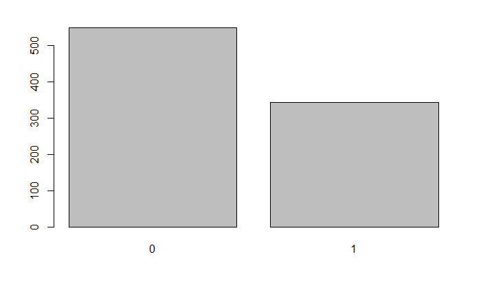

```r
barplot(table(titanic$Survived))
```

С зададени цветове, имена на категориите и заглавие

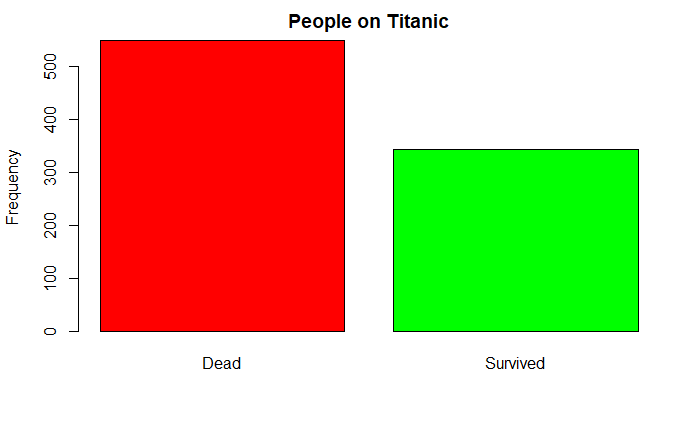

```r
barplot(table(titanic$Survived),
        names.arg = c("Dead", "Survived"),
        col = c("red", "green"),
        main = "People on Titanic",
        ylab = "Frequency")
```

Барплот на относителните честоти

```r
table(titanic$Survived)/length(titanic$Survived)
```

```
    0     1
0.616 0.384
```

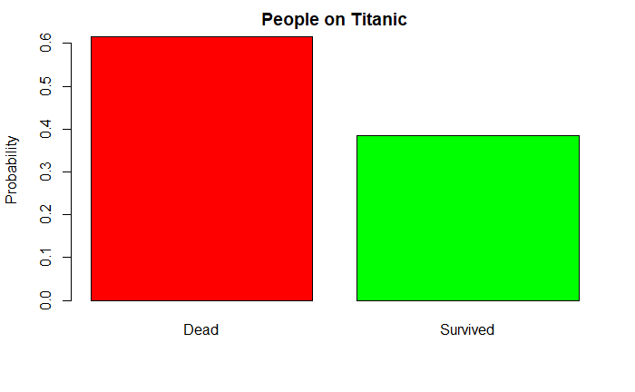

```r
barplot(table(titanic$Survived)/length(titanic$Survived),
        names.arg = c("Dead", "Survived"),
        col = c("red", "green"),
        main = "People on Titanic",
        ylab = "Probability")
```

- Кръгова диаграма (Pie Chart)

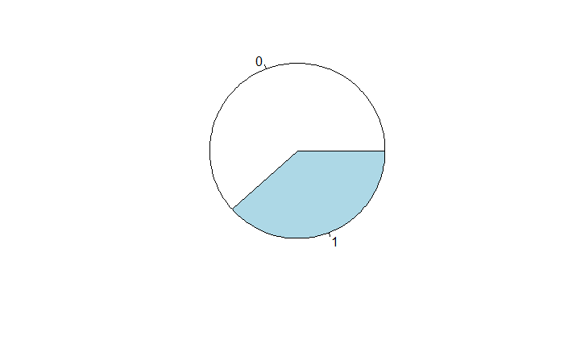

```r
pie(table(titanic$Survived))
```

С зададени цветове, имена на категориите и заглавие

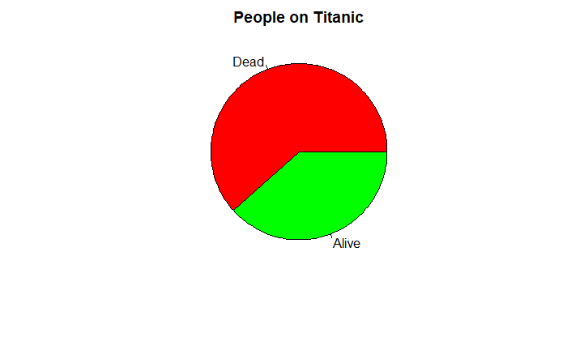

```r
pie(table(titanic$Survived),
    labels = c("Dead", "Alive"),
    col = c("Red", "green"),
    main = "People on Titanic")
```

### Pclass

```r
head(titanic$Pclass)
```

```
[1] 3 1 3 1 3 3
```

```r
head(factor(titanic$Pclass))
```

```
[1] 3 1 3 1 3 3
Levels: 1 2 3
```

Можете да направите същото…

### Sex

```r
head(titanic$Sex)
```

```
[1] male   female female female male   male
Levels: female male
```

```r
head(factor(titanic$Sex))
```

```
[1] male   female female female male   male
Levels: female male
```

Можете да направите същото…

### Embarked

```r
head(titanic$Embarked)
```

```
[1] S C S S S Q
Levels:  C Q S
```

```r
head(factor(titanic$Emarked))
```

```
factor(0)
Levels:
```

Можете да направите същото…